# Coursera Practical Machine Learning Course Project

Anne Strader

5/20/2021

## Executive Summary

Using devices such as *Jawbone Up*, *Nike Fuelband*, and *Fitbit* it is now possible to collect a large amount of data about personal activity relatively inexpensively. These type of devices are part of the quantified self movement - a group of enthusiasts who take measurements about themselves regularly to improve their health, to find patterns in their behavior, or because they are tech geeks. One thing that people regularly do is quantify how *much* of a particular activity they do, but they rarely quantify *how well they do it*.

The data for this project come from this source: http://web.archive.org/web/20161224072740/http:/groupware.les.inf.puc-rio.br/har.

## Getting and Cleaning the Dataset

In preparation for the analysis, necessary R libraries are loaded:

```r
library(knitr)
library(caret)
library(corrplot)
library(rattle)
library(randomForest)
```

The training and test data are then downloaded:

```r
# define the URLs where the data are stored
trainURL <- "https://d396qusza40orc.cloudfront.net/predmachlearn/pml-training.csv"  # training data set
testURL <- "https://d396qusza40orc.cloudfront.net/predmachlearn/pml-testing.csv"  # test data set

# define the source data filenames
fileTrainData <- "pml-training.csv"  # training data set
fileTestData <- "pml-testing.csv"  # test data set

# check if datasets have already been downloaded in working directory, and download them if not
if (!file.exists(fileTrainData)) {  # training data set
  download.file(trainURL, fileTrainData)
}
if (!file.exists(fileTestData)) {  # test data set
  download.file(testURL, fileTestData)
}
```

The test data set is considered to be a final “validation” set, whereas the training data set will be subdivided into a smaller training set (70% of the data) and a test set (30% of the data).

```r
# read in both data sets
trainingData <- read.csv(fileTrainData)  # training data set
validationSet <- read.csv(fileTestData)  # test data set (validation)
```

Let’s look at a summary of the training data set, in order to identify the predicted variable:

```r
str(trainingData)
```

```
## 'data.frame':    19622 obs. of  160 variables:
##  $ X                       : int  1 2 3 4 5 6 7 8 9 10 ...
##  $ user_name               : Factor w/ 6 levels "adelmo","carlitos",..: 2 2 2 2 2 2 2 2 2 2 ...
##  $ raw_timestamp_part_1    : int  1323084231 1323084231 1323084231 1323084232 1323084232 1323084232 1323084232 1323084232 1323084232 1323084232 ...
##  $ raw_timestamp_part_2    : int  788290 808298 820366 120339 196328 304277 368296 440390 484323 484434 ...
##  $ cvtd_timestamp          : Factor w/ 20 levels "02/12/2011 13:32",..: 9 9 9 9 9 9 9 9 9 9 ...
##  $ new_window              : Factor w/ 2 levels "no","yes": 1 1 1 1 1 1 1 1 1 1 ...
##  $ num_window              : int  11 11 11 12 12 12 12 12 12 12 ...
##  $ roll_belt               : num  1.41 1.41 1.42 1.48 1.48 1.45 1.42 1.42 1.43 1.45 ...
##  $ pitch_belt              : num  8.07 8.07 8.07 8.05 8.07 8.06 8.09 8.13 8.16 8.17 ...
##  $ yaw_belt                : num  -94.4 -94.4 -94.4 -94.4 -94.4 -94.4 -94.4 -94.4 -94.4 -94.4 ...
##  $ total_accel_belt        : int  3 3 3 3 3 3 3 3 3 3 ...
##  $ kurtosis_roll_belt      : Factor w/ 397 levels "","-0.016850",..: 1 1 1 1 1 1 1 1 1 1 ...
##  $ kurtosis_picth_belt     : Factor w/ 317 levels "","-0.021887",..: 1 1 1 1 1 1 1 1 1 1 ...
##  $ kurtosis_yaw_belt       : Factor w/ 2 levels "","#DIV/0!": 1 1 1 1 1 1 1 1 1 1 ...
```

[output cut: 86 more lines]

```r
head(trainingData)
```

```
##   X user_name raw_timestamp_part_1 raw_timestamp_part_2   cvtd_timestamp
## 1 1  carlitos           1323084231               788290 05/12/2011 11:23
## 2 2  carlitos           1323084231               808298 05/12/2011 11:23
## 3 3  carlitos           1323084231               820366 05/12/2011 11:23
## 4 4  carlitos           1323084232               120339 05/12/2011 11:23
## 5 5  carlitos           1323084232               196328 05/12/2011 11:23
## 6 6  carlitos           1323084232               304277 05/12/2011 11:23
##   new_window num_window roll_belt pitch_belt yaw_belt total_accel_belt
## 1         no         11      1.41       8.07    -94.4                3
## 2         no         11      1.41       8.07    -94.4                3
## 3         no         11      1.42       8.07    -94.4                3
## 4         no         12      1.48       8.05    -94.4                3
## 5         no         12      1.48       8.07    -94.4                3
## 6         no         12      1.45       8.06    -94.4                3
##   kurtosis_roll_belt kurtosis_picth_belt kurtosis_yaw_belt skewness_roll_belt
```

[output cut: 251 more lines]

The predicted variable, or way in which the dumbbell exercise was performed, is “classe”. There are 160 variables and 19622 observations.

```r
# subdivide training data set into training and test set
set.seed(242)
inTrainingSet <- createDataPartition(trainingData$classe, p=0.7, list=FALSE)
trainingSet <- trainingData[inTrainingSet,]
testingSet <- trainingData[-inTrainingSet,]
```

Features that will not add any substantial information to the prediction model should be removed. These include ID variables, variables with mostly NA values, and variables with near-zero variance.

From the summary, the first five columns of the dataset can easily be interpreted as ID variables. These are removed from the training, testing and validation sets:

```r
trainingSet <- trainingSet[, -(1:5)]
testingSet <- testingSet[, -(1:5)]
validationSet <- validationSet[, -(1:5)]
```

Next, variables with “NA” values for at least 90% of observations are removed from the training, testing and validation sets, with the percentage of “NA” values based on the training set:

```r
mostlyNAvals <- sapply(trainingSet, function(x) mean(is.na(x))) > 0.90
trainingSet <- trainingSet[, mostlyNAvals==FALSE]
testingSet <- testingSet[, mostlyNAvals==FALSE]
validationSet <- validationSet[, mostlyNAvals==FALSE]
```

Finally, near-zero variance variables are removed from the training, testing and validation sets, based on the variables’ variances in the training set:

```r
nearZeroVar <- nearZeroVar(trainingSet)
trainingSet <- trainingSet[, -nearZeroVar]
testingSet <- testingSet[, -nearZeroVar]
validationSet <- validationSet[, -nearZeroVar]
```

```r
dim(trainingSet)
```

```
## [1] 13737    54
```

The total number of variables has been reduced from 160 to 54.

## Exploratory Data Analysis

To qualitatively determine if the number of features should be further reduced, the correlation values between all predictor variable pairs are plotted using the training set:

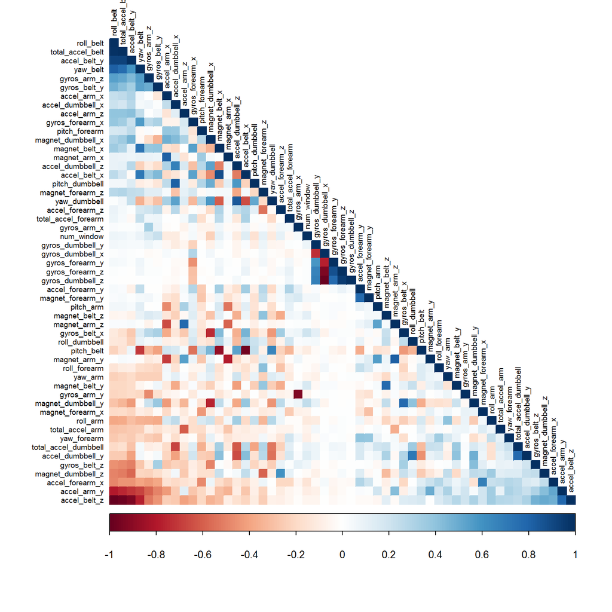

```r
correlations <- cor(trainingSet[, -length(names(trainingSet))])
par(xpd=TRUE)
corrplot(correlations, method="color", type="lower", tl.cex=0.6, tl.col=rgb(0, 0, 0), order = "FPC", mar = c(2, 2, 2, 2))
```

Although most predictor variable pairs have a low correlation, there are some variable pairs that appear to be nearly perfectly correlated or anticorrelated. Applying Principal Component Analysis (PCA) would further reduce the number of features. However, the interpretability of the prediction model would also be greatly reduced by creating features out of combinations of individual predictor variables. Ideally, the resulting prediction model could be used to also provide user specific feedback regarding why an exercise was performed incorrectly. Therefore, PCA will not be applied here.

## Prediction Model Building and Model Selection

Before the models are built, the cross-validation parameters are set:

```r
cvControl <- trainControl(method="cv", number=5, verboseIter=FALSE)
```

### Model 1: Support-Vector Machine

The support-vector machine model is built from the training data:

```r
model_SVM <- train(classe ~ ., data=trainingSet, method="svmLinear", trcontrol=cvControl, tuneLength=5, verbose=F)
```

and used to predict activity type from the testing data:

```r
predictions_SVM <- predict(model_SVM, testingSet)
```

with the following results:

```r
results_SVM <- confusionMatrix(predictions_SVM, factor(testingSet$classe))
results_SVM
```

```
## Confusion Matrix and Statistics
##
##           Reference
## Prediction    A    B    C    D    E
##          A 1542  154   76   54   38
##          B   47  821  105   38  118
##          C   36   66  786  102   75
##          D   41   19   25  727   64
##          E    8   79   34   43  787
##
## Overall Statistics
##
##                Accuracy : 0.7924
##                  95% CI : (0.7818, 0.8027)
##     No Information Rate : 0.2845
##     P-Value [Acc > NIR] : < 2.2e-16
##
##                   Kappa : 0.7362
##
##  Mcnemar's Test P-Value : < 2.2e-16
##
## Statistics by Class:
##
##                      Class: A Class: B Class: C Class: D Class: E
## Sensitivity            0.9211   0.7208   0.7661   0.7541   0.7274
## Specificity            0.9235   0.9351   0.9426   0.9697   0.9659
## Pos Pred Value         0.8273   0.7272   0.7380   0.8299   0.8275
## Neg Pred Value         0.9672   0.9331   0.9502   0.9527   0.9402
## Prevalence             0.2845   0.1935   0.1743   0.1638   0.1839
## Detection Rate         0.2620   0.1395   0.1336   0.1235   0.1337
## Detection Prevalence   0.3167   0.1918   0.1810   0.1489   0.1616
## Balanced Accuracy      0.9223   0.8280   0.8543   0.8619   0.8466
```

The accuracy of the support-vector machine model is **0.7924** with an out-of-sample error of **0.2076**.

### Model 2: Decision Tree Model

The decision tree model is built from the training data:

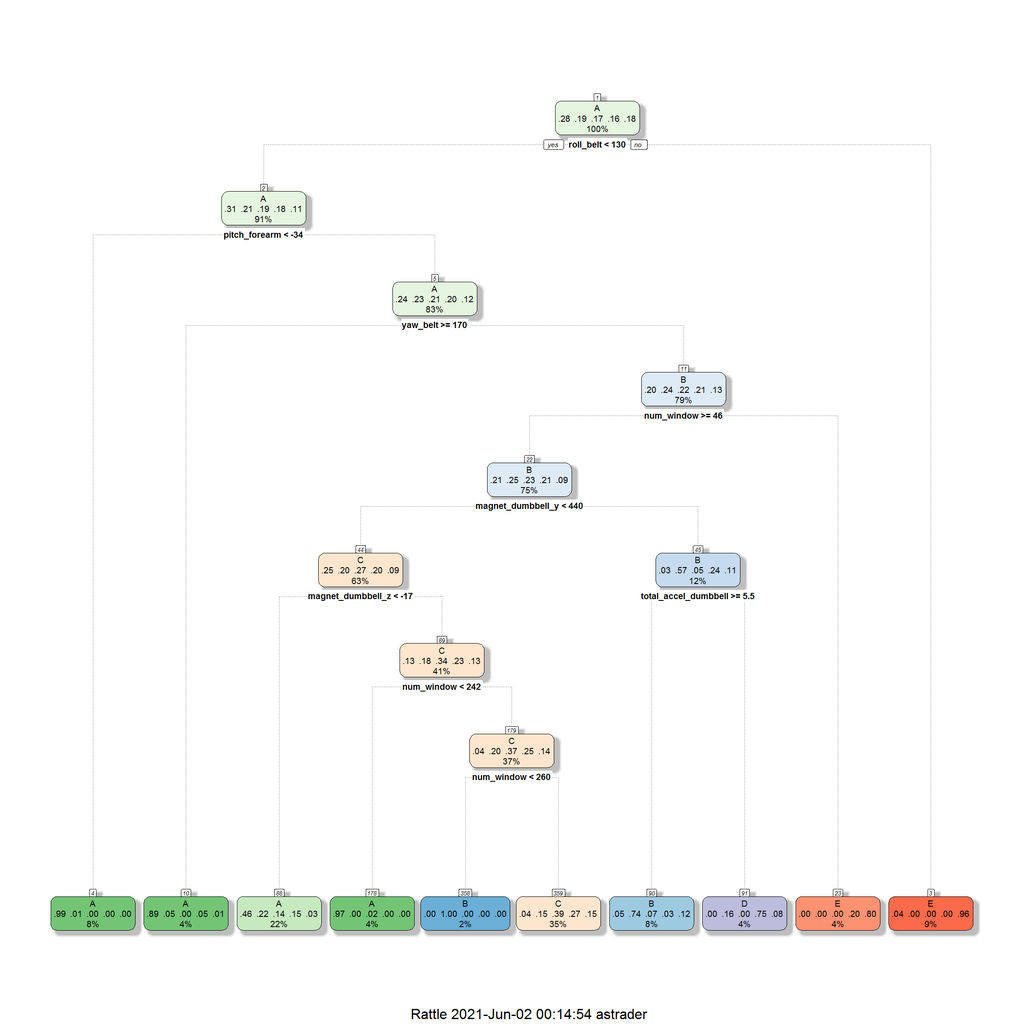

```r
model_DT <- train(classe ~ ., data=trainingSet, method="rpart", trControl=cvControl, tuneLength=5)
fancyRpartPlot(model_DT$finalModel)
```

and used to predict activity type from the testing data:

```r
predictions_DT <- predict(model_DT, testingSet)
```

with the following results:

```r
results_DT <- confusionMatrix(predictions_DT, factor(testingSet$classe))
results_DT
```

```
## Confusion Matrix and Statistics
##
##           Reference
## Prediction    A    B    C    D    E
##          A 1535  322  198  190   23
##          B   27  475   33    9   59
##          C   87  308  794  554  278
##          D    0   34    1  168   19
##          E   25    0    0   43  703
##
## Overall Statistics
##
##                Accuracy : 0.6245
##                  95% CI : (0.612, 0.6369)
##     No Information Rate : 0.2845
##     P-Value [Acc > NIR] : < 2.2e-16
##
##                   Kappa : 0.5188
##
##  Mcnemar's Test P-Value : < 2.2e-16
##
## Statistics by Class:
##
##                      Class: A Class: B Class: C Class: D Class: E
## Sensitivity            0.9170  0.41703   0.7739  0.17427   0.6497
## Specificity            0.8259  0.97303   0.7475  0.98903   0.9858
## Pos Pred Value         0.6768  0.78773   0.3929  0.75676   0.9118
## Neg Pred Value         0.9616  0.87429   0.9400  0.85944   0.9259
## Prevalence             0.2845  0.19354   0.1743  0.16381   0.1839
## Detection Rate         0.2608  0.08071   0.1349  0.02855   0.1195
## Detection Prevalence   0.3854  0.10246   0.3434  0.03772   0.1310
## Balanced Accuracy      0.8714  0.69503   0.7607  0.58165   0.8178
```

The accuracy of the decision tree model is **0.6245** with an out-of-sample error of **0.3755**.

### Model 3: Random Forest Model

The random forest model is built from the training data:

```r
model_RF <- train(classe ~ ., data=trainingSet, method="rf", trainControl=cvControl, tuneLength=5)
```

and used to predict activity type from the testing data:

```r
predictions_RF <- predict(model_RF, testingSet)
```

with the following results:

```r
results_RF <- confusionMatrix(predictions_RF, factor(testingSet$classe))
results_RF
```

```
## Confusion Matrix and Statistics
##
##           Reference
## Prediction    A    B    C    D    E
##          A 1674    4    0    0    0
##          B    0 1135    3    0    0
##          C    0    0 1023    4    0
##          D    0    0    0  960    3
##          E    0    0    0    0 1079
##
## Overall Statistics
##
##                Accuracy : 0.9976
##                  95% CI : (0.996, 0.9987)
##     No Information Rate : 0.2845
##     P-Value [Acc > NIR] : < 2.2e-16
##
##                   Kappa : 0.997
##
##  Mcnemar's Test P-Value : NA
##
## Statistics by Class:
##
##                      Class: A Class: B Class: C Class: D Class: E
## Sensitivity            1.0000   0.9965   0.9971   0.9959   0.9972
## Specificity            0.9991   0.9994   0.9992   0.9994   1.0000
## Pos Pred Value         0.9976   0.9974   0.9961   0.9969   1.0000
## Neg Pred Value         1.0000   0.9992   0.9994   0.9992   0.9994
## Prevalence             0.2845   0.1935   0.1743   0.1638   0.1839
## Detection Rate         0.2845   0.1929   0.1738   0.1631   0.1833
## Detection Prevalence   0.2851   0.1934   0.1745   0.1636   0.1833
## Balanced Accuracy      0.9995   0.9979   0.9981   0.9976   0.9986
```

The accuracy of the random forest model is **0.9976** with an out-of-sample error of **0.0024**.

Because the out-of-sample error is substantially lower when applying the random forest model compared to the decision tree and support-vector machine model, the random forest model is chosen to predict the class of activity from the validation data.

## Predictions from Validation Data

In the last step, activity type is predicted from the validation set. All data pre-processing has already been applied to the validation set in previous steps.

```r
predictValidation <- predict(model_RF, validationSet)
predictValidation
```

```
##  [1] B A B A A E D B A A B C B A E E A B B B
## Levels: A B C D E
```